# Homework 11

Solutions will be available after Monday, November 9, 2026.

## Question 1: Implementing K-means

K-means is a relatively simple algorithm that we can write ourselves. For Questions 1 and 2, do not use an existing function that performs K-means directly.

Generate 10 observations with two independent standard normal coordinates. Set a random seed and report it. Randomly assign the observations to $K=2$ clusters, making sure neither cluster is empty. Let $C(i)$ denote the cluster assigned to observation $x_i$, and let $m_k$ denote the mean of cluster $k$.

1. Perform one iteration: calculate the cluster means, then assign each observation to its closest mean using Euclidean distance. Report the means and updated assignments, and plot the observations colored by their updated assignments.
2. Write a function that repeats these two steps until the assignments stop changing or a specified maximum number of iterations is reached. Your function should work for a data matrix with any number of variables and a chosen number of clusters $K$. Start from a nonempty assignment to each cluster; if a cluster becomes empty during iteration, keep its previous mean. Recalculate the cluster means from the final assignments before returning them. Return the final assignments, cluster means, and within-cluster sum of squares,

   $$\sum_{k=1}^K\sum_{i:\,C(i)=k}\lVert x_i-m_k\rVert^2.$$
3. Apply your function to the same 10 observations from two different random initial assignments. Report the final plots, cluster means, and within-cluster sums of squares. Do the two runs produce the same grouping and objective value? Explain your findings.

### Question 1 answer

I used seed **11011** and generated one $10 \times 2$ matrix of independent standard normal observations. The initial assignment was created by shuffling five labels for each cluster, so both clusters were nonempty. The code reports the starting means, one nearest-center reassignment, and the requested scatterplot.

|  | variable 1 | variable 2 |
| --- | --- | --- |
| cluster 1 | 0.149038 | 0.218114 |
| cluster 2 | -0.042030 | 0.434719 |

|  | observation | initial | updated |
| --- | --- | --- | --- |
| 0 | 1 | 2 | 2 |
| 1 | 2 | 2 | 1 |
| 2 | 3 | 1 | 1 |
| 3 | 4 | 1 | 2 |
| 4 | 5 | 1 | 1 |
| 5 | 6 | 1 | 2 |
| 6 | 7 | 1 | 1 |
| 7 | 8 | 2 | 1 |
| 8 | 9 | 2 | 2 |
| 9 | 10 | 2 | 1 |

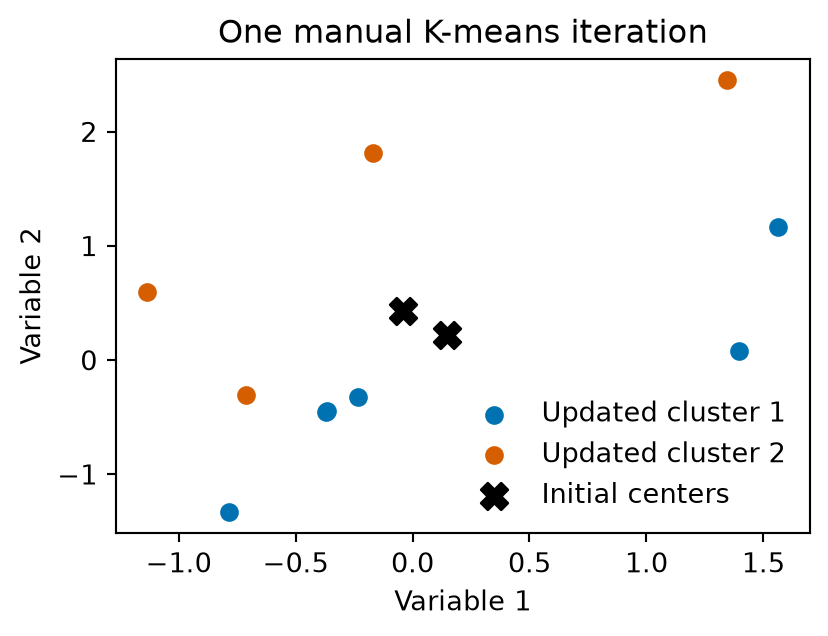

|  | run | initial | final | WCSS | iterations | converged |
| --- | --- | --- | --- | --- | --- | --- |
| 0 | A | [2, 2, 1, 1, 1, 1, 1, 2, 2, 2] | [2, 1, 1, 1, 1, 1, 2, 1, 2, 1] | 8.632486 | 4 | True |
| 1 | B | [2, 1, 1, 2, 1, 2, 1, 1, 2, 2] | [2, 1, 1, 1, 1, 1, 2, 1, 2, 1] | 8.632486 | 4 | True |

|  | variable 1 | variable 2 |
| --- | --- | --- |
| 0 | -0.314905 | -0.309989 |
| 1 | 0.913125 | 1.811363 |

|  | variable 1 | variable 2 |
| --- | --- | --- |
| 0 | -0.314905 | -0.309989 |
| 1 | 0.913125 | 1.811363 |

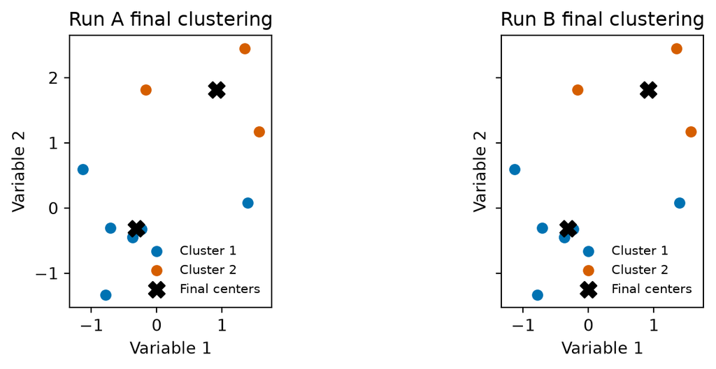

The two runs use the same observations and compare partitions after allowing for label switching. Different starts can reach different local minima, even if these particular starts happen to agree.

## Question 2: Image color compression

Pick your favorite color image and use your K-means function from Question 1 to cluster its pixels. For computational efficiency, resize the image to no more than $200\times200$ pixels and use its three RGB color channels.

1. Plot the original image and report its dimensions. Transform it into a data matrix with one observation per pixel and three variables: red, green, and blue. Report the dimensions of this matrix.
2. For $K=2,3,5,10$, apply your function to the pixel data. Report the cluster means and within-cluster sum of squares for each $K$. Reconstruct and plot each compressed image by replacing every pixel with its assigned cluster mean. Use the same RGB scale for all fits.
3. Which value of $K$ would you choose for this image? Briefly justify your choice using the reconstructed images and the within-cluster sums of squares.

### Question 2 answer

For this exercise, I chose the scikit-learn sample image `china.jpg`. Its original dimensions are reported by the code; it is resized to at most 200 pixels on its longest side, converted to RGB, and reshaped so each pixel is one observation with three variables. The same custom `my_kmeans()` function is used for $K=2,3,5,10$.

```
Image source: sklearn sample china.jpg; original=(427, 640, 3); resized=(133, 200, 3); pixel matrix=(26600, 3)
```

| K | WCSS | iterations | converged |
| --- | --- | --- | --- |
| 2 | 90,000,306 | 5 | True |
| 3 | 48,751,747 | 26 | True |
| 5 | 26,289,506 | 40 | True |
| 10 | 11,852,155 | 71 | True |

```
K=2 RGB centers: [[79.4, 71.6, 53.2], [210.8, 220.1, 229.6]]
K=3 RGB centers: [[123.6, 112.4, 86.6], [213.8, 224.1, 234.9], [47.8, 43.4, 32.6]]
K=5 RGB centers: [[179.2, 186.4, 184.6], [87.0, 80.7, 56.6], [220.1, 230.7, 243.8], [33.2, 30.2, 23.4], [138.9, 120.9, 95.3]]
K=10 RGB centers: [[79.3, 74.1, 56.5], [20.9, 18.8, 13.1], [234.4, 240.9, 249.5], [111.7, 113.6, 99.2], [112.3, 99.8, 55.7], [180.5, 118.0, 81.2], [150.6, 153.7, 145.3], [183.6, 192.6, 191.4], [198.6, 215.0, 233.8], [50.6, 46.0, 36.9]]
```

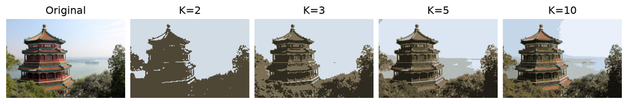

The WCSS decreases as $K$ increases because more representative colors are available. In the reconstructed images, $K=2$ is extremely coarse, $K=3$ recovers more architectural structure, $K=5$ separates the main building, sky, and vegetation regions reasonably, and $K=10$ restores additional roof/building colors and finer variation. Although $K=10$ has substantially smaller WCSS and better fidelity, I prefer **$K=5$** because it gives stronger color compression while retaining the main visible structure. This is an image-specific compromise rather than an elbow theorem or a universal optimum; WCSS alone cannot justify taking $K$ arbitrarily large, since $K=n$ can drive approximation error toward zero.

## Question 3: Hierarchical clustering of cars

The file `data/mtcars.csv` contains 11 numerical variables for 32 cars, including fuel economy, horsepower, and weight. The `car` column gives the model names; use it to label observations, not as a clustering variable. You may use existing hierarchical clustering functions for this question.

1. Standardize each numerical variable to have mean 0 and standard deviation 1. Using Euclidean distance, perform hierarchical clustering with single, complete, and average linkage. Plot the three dendrograms with the car names and compare the results.
2. Choose one linkage method and a number of clusters that you consider reasonable. Report the cluster memberships and a table of cluster means on the original variable scales. Describe the main characteristics of the groups and explain your choice using the dendrogram and table. Briefly explain why standardizing the variables matters for this analysis.

### Question 3 answer

I excluded the `car` label from the clustering variables and standardized the 11 numeric variables before calculating Euclidean hierarchical clustering. Standardization is important because Euclidean distance is scale-sensitive; otherwise variables with larger numerical units could dominate. The three dendrograms below use single, complete, and average linkage. Single linkage shows the expected chaining behavior, while complete linkage creates more compact, clearly separated branches; average linkage is intermediate. I selected complete linkage with $K=3$ because its dendrogram shows three visually interpretable major branches before the next high-level merges, yielding reasonably sized groups of 15, 12, and 5 rather than singleton-style clusters.

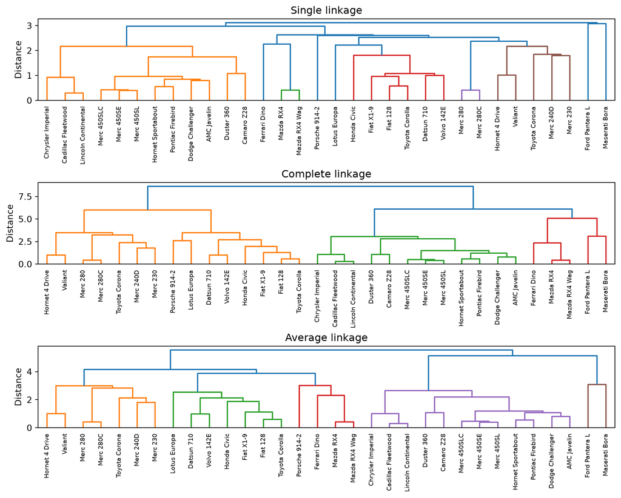

|  | car | cluster |
| --- | --- | --- |
| 2 | Datsun 710 | 1 |
| 17 | Fiat 128 | 1 |
| 25 | Fiat X1-9 | 1 |
| 18 | Honda Civic | 1 |
| 3 | Hornet 4 Drive | 1 |
| 27 | Lotus Europa | 1 |
| 8 | Merc 230 | 1 |
| 7 | Merc 240D | 1 |
| 9 | Merc 280 | 1 |
| 10 | Merc 280C | 1 |
| 26 | Porsche 914-2 | 1 |
| 19 | Toyota Corolla | 1 |
| 20 | Toyota Corona | 1 |
| 5 | Valiant | 1 |
| 31 | Volvo 142E | 1 |
| 22 | AMC Javelin | 2 |
| 14 | Cadillac Fleetwood | 2 |
| 23 | Camaro Z28 | 2 |
| 16 | Chrysler Imperial | 2 |
| 21 | Dodge Challenger | 2 |
| 6 | Duster 360 | 2 |
| 4 | Hornet Sportabout | 2 |
| 15 | Lincoln Continental | 2 |
| 11 | Merc 450SE | 2 |
| 12 | Merc 450SL | 2 |
| 13 | Merc 450SLC | 2 |
| 24 | Pontiac Firebird | 2 |
| 29 | Ferrari Dino | 3 |
| 28 | Ford Pantera L | 3 |
| 30 | Maserati Bora | 3 |
| 0 | Mazda RX4 | 3 |
| 1 | Mazda RX4 Wag | 3 |

| cluster | mpg | cyl | disp | hp | drat | wt | qsec | vs | am | gear | carb |
| --- | --- | --- | --- | --- | --- | --- | --- | --- | --- | --- | --- |
| 1 | 24.65 | 4.53 | 131.65 | 91.33 | 3.90 | 2.58 | 19.16 | 0.93 | 0.53 | 3.93 | 1.80 |
| 2 | 15.05 | 8.00 | 357.62 | 194.17 | 3.12 | 4.10 | 17.14 | 0.00 | 0.00 | 3.00 | 3.08 |
| 3 | 18.50 | 6.80 | 223.40 | 198.80 | 3.84 | 3.00 | 15.62 | 0.00 | 1.00 | 4.60 | 5.20 |

```
Cluster sizes: {1: 15, 2: 12, 3: 5}
```

The original-scale means show that Cluster 1 (n=15) is lighter and more fuel-efficient (mpg 24.65, wt 2.58), with lower displacement and horsepower and mostly four-cylinder/straight-engine cars. Cluster 2 (n=12) is the heaviest and least fuel-efficient group (mpg 15.05, wt 4.10), averaging exactly eight cylinders, large displacement, high horsepower, and automatic transmission. Cluster 3 (n=5) is performance-oriented: it has high horsepower (198.80), is considerably lighter than Cluster 2 (wt 3.00), has the shortest mean qsec (15.62), and is entirely manual with higher mean gear and carb values. Thus Clusters 2 and 3 both have high horsepower, but Cluster 2 is heavier, lower-mpg, and automatic, whereas Cluster 3 is lighter, manual, and faster by qsec. These coherent original-scale differences support the complete-linkage cut at $K=3$ alongside the dendrogram structure.